# tmp

- **Name**: `Joining2`
- **Fully Qualified Name**: `org.openprovenance.templates.generic.Joining2`
- **IRI**: https://openprovenance.org/templates/org/openprovenance/templates/generic/Joining2
- **Purpose**: The template `Joining2` describes the transformation of two inputs resulting in a single output.
- **Context**: It is a general transformation applicable to many different contexts.
- **Design considerations**: Relations rigorously linking nodes using pre-defined triangles.
- **Automation**: ttfs/config-generic.json

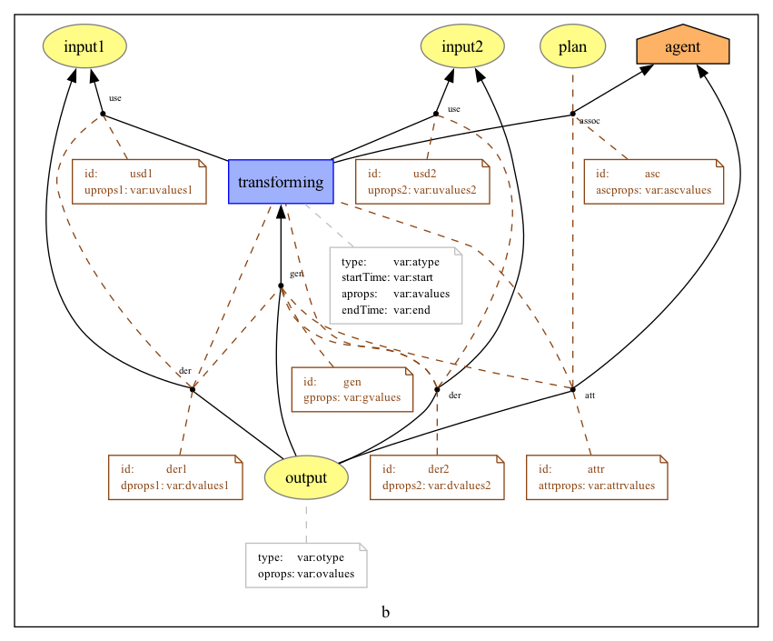

Figure 1: org.openprovenance.templates.generic.Joining2

- **Details**:

  There are three entities directly related to the transformation: `input1`, `input2` and `output`; an activity `transforming`; an agent `agent`; and an associated plan `plan`.

  The pattern has multiple applications, including binary arithmetic operations (e.g., addition of two numbers), concatenating two files, and merging two provenance graphs.